# Project2

jeromej2

7/29/2018

## Model selection

I wanted to see if the advances in exoplanetary discovery were getting more accurate in regards to predicting the orbit of extra-solar bodies. Are we getting better in finding panets in the *‘Goldilocks Zone’*? Could we find a second home?

The model selection started with a full base fit of the Orbital semi-Major axis as the response and the selected parameters as predictors. Looking at the pairs plot, we can see a few obviously logarithmic relationships between predictors, but for completeness, I started with a simple additive model. I took this model and ran both AIC and BIC to see if we could improve the $R^{2}$. The base model run under backwards BIC returned the best additive model, but the $R^{2}$ was less than 30%.

Next I tried a log transformation on the response, and three of the predictors, I used $e^{predictor}$ of the predictors already in log space, and one interactive term of $log(Stellar Radius * e^{Stellar Surface Gravity})$, as these terms showed high Collinearity and strong Variance Inflation on the base model. The log fit showed promise, so I used both backwards and forwards AIC to see if a better model could be had. In the end of those tests, the original log fit worked out the best.

Lastly, I created a 90% confidence interval for predictions grouped by year. I dropped the one observation from 1989 as I didn’t want only one point to overly influence the predictions. I then created a mean confidence interval per year, and plotted the time series. Although not flawless, there appears to be a downward trend in confidence span, inferring that we may be getting more proficient in the discovery of new planets on other systems.

## Methods

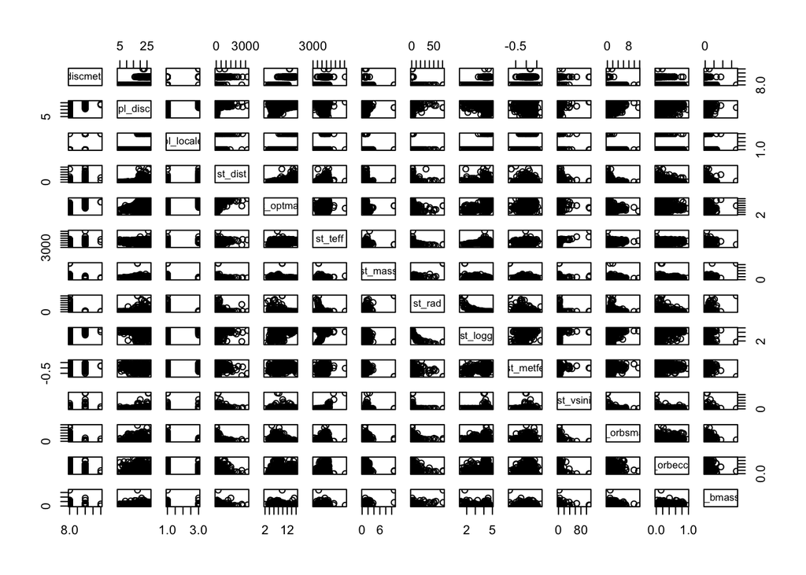

```r
pairs(planets_good)
```

```r
anova(base,base_aic)
```

```
## Analysis of Variance Table
##
## Model 1: pl_orbsmax ~ pl_discmethod + pl_disc + pl_locale + st_dist +
##     st_optmag + st_teff + st_mass + st_rad + st_logg + st_metfe +
##     st_vsini + pl_orbeccen + pl_bmasse
## Model 2: pl_orbsmax ~ pl_discmethod + pl_disc + st_optmag + st_teff +
##     st_rad + st_vsini + pl_orbeccen + pl_bmasse
##   Res.Df RSS Df Sum of Sq    F Pr(>F)
## 1    556 806
## 2    561 811 -5     -4.17 0.57   0.72
```

```r
anova(base,base_bic)
```

```
## Analysis of Variance Table
##
## Model 1: pl_orbsmax ~ pl_discmethod + pl_disc + pl_locale + st_dist +
##     st_optmag + st_teff + st_mass + st_rad + st_logg + st_metfe +
##     st_vsini + pl_orbeccen + pl_bmasse
## Model 2: pl_orbsmax ~ pl_discmethod + pl_orbeccen + pl_bmasse
##   Res.Df RSS  Df Sum of Sq    F  Pr(>F)
## 1    556 806
## 2    588 931 -32      -125 2.69 2.8e-06 ***
## ---
## Signif. codes:  0 '***' 0.001 '**' 0.01 '*' 0.05 '.' 0.1 ' ' 1
```

```r
summary(base_bic)
```

```
##
## Call:
## lm(formula = pl_orbsmax ~ pl_discmethod + pl_orbeccen + pl_bmasse,
##     data = planets_good)
##
## Residuals:
##    Min     1Q Median     3Q    Max
## -3.235 -0.789 -0.088  0.235 10.171
##
## Coefficients:
##                                        Estimate Std. Error t value Pr(>|t|)
## (Intercept)                           1.1294997  0.0912617   12.38  < 2e-16 ***
## pl_discmethodTransit                 -1.2351458  0.1157519  -10.67  < 2e-16 ***
## pl_discmethodTransitTimingVariations -0.5820457  0.8926107   -0.65     0.51
## pl_orbeccen                           1.3272979  0.2746723    4.83  1.7e-06 ***
## pl_bmasse                             0.0001673  0.0000408    4.10  4.8e-05 ***
## ---
## Signif. codes:  0 '***' 0.001 '**' 0.01 '*' 0.05 '.' 0.1 ' ' 1
##
## Residual standard error: 1.26 on 588 degrees of freedom
## Multiple R-squared:  0.279,  Adjusted R-squared:  0.274
## F-statistic: 56.9 on 4 and 588 DF,  p-value: <2e-16
```

```r
calc_loocv_rmse(base_bic)
```

```
## [1] 1.268
```

```r
car::vif(base)
```

```
##                GVIF Df GVIF^(1/(2*Df))
## pl_discmethod 5.508  2           1.532
## pl_disc       3.060 23           1.025
## pl_locale     2.085  1           1.444
## st_dist       3.098  1           1.760
## st_optmag     7.394  1           2.719
## st_teff       2.659  1           1.631
## st_mass       2.309  1           1.519
## st_rad        4.946  1           2.224
## st_logg       4.656  1           2.158
## st_metfe      1.299  1           1.140
## st_vsini      1.663  1           1.290
## pl_orbeccen   1.261  1           1.123
## pl_bmasse     1.818  1           1.348
```

```r
anova(log_base, log_base_aic_b)
```

```
## Analysis of Variance Table
##
## Model 1: log(pl_orbsmax) ~ pl_discmethod + log(st_dist) + log(st_teff) +
##     log(I(st_rad * exp(st_logg))) + exp(st_metfe) + st_vsini +
##     exp(pl_orbeccen) + log(pl_bmasse)
## Model 2: log(pl_orbsmax) ~ pl_discmethod + log(I(st_rad * exp(st_logg))) +
##     exp(st_metfe) + st_vsini + exp(pl_orbeccen) + log(pl_bmasse)
##   Res.Df RSS Df Sum of Sq  F Pr(>F)
## 1    583 691
## 2    585 693 -2     -2.38  1   0.37
```

```r
anova(log_base, log_base_aic_f)
```

```
## Analysis of Variance Table
##
## Model 1: log(pl_orbsmax) ~ pl_discmethod + log(st_dist) + log(st_teff) +
##     log(I(st_rad * exp(st_logg))) + exp(st_metfe) + st_vsini +
##     exp(pl_orbeccen) + log(pl_bmasse)
## Model 2: log(pl_orbsmax) ~ pl_discmethod + log(pl_bmasse) + exp(pl_orbeccen) +
##     exp(st_metfe) + log(I(st_rad * exp(st_logg))) + st_vsini
##   Res.Df RSS Df Sum of Sq  F Pr(>F)
## 1    583 691
## 2    585 693 -2     -2.38  1   0.37
```

```r
car::vif(log_base)
```

```
##                                GVIF Df GVIF^(1/(2*Df))
## pl_discmethod                 3.852  2           1.401
## log(st_dist)                  3.592  1           1.895
## log(st_teff)                  1.399  1           1.183
## log(I(st_rad * exp(st_logg))) 1.668  1           1.291
## exp(st_metfe)                 1.096  1           1.047
## st_vsini                      1.344  1           1.159
## exp(pl_orbeccen)              1.199  1           1.095
## log(pl_bmasse)                1.515  1           1.231
```

```r
summary(log_base)
```

```
##
## Call:
## lm(formula = log(pl_orbsmax) ~ pl_discmethod + log(st_dist) +
##     log(st_teff) + log(I(st_rad * exp(st_logg))) + exp(st_metfe) +
##     st_vsini + exp(pl_orbeccen) + log(pl_bmasse), data = planets_good)
##
## Residuals:
##    Min     1Q Median     3Q    Max
## -3.091 -0.677 -0.007  0.698  3.037
##
## Coefficients:
##                                      Estimate Std. Error t value Pr(>|t|)
## (Intercept)                          -9.88761    3.84970   -2.57   0.0105 *
## pl_discmethodTransit                 -2.06086    0.18706  -11.02  < 2e-16 ***
## pl_discmethodTransitTimingVariations -0.27535    0.79067   -0.35   0.7278
## log(st_dist)                         -0.02170    0.06486   -0.33   0.7381
## log(st_teff)                          0.61486    0.44397    1.38   0.1666
## log(I(st_rad * exp(st_logg)))         0.53858    0.20065    2.68   0.0075 **
## exp(st_metfe)                        -0.63377    0.21056   -3.01   0.0027 **
## st_vsini                             -0.01864    0.00643   -2.90   0.0039 **
## exp(pl_orbeccen)                      1.03808    0.17168    6.05  2.6e-09 ***
## log(pl_bmasse)                        0.24384    0.03164    7.71  5.6e-14 ***
## ---
## Signif. codes:  0 '***' 0.001 '**' 0.01 '*' 0.05 '.' 0.1 ' ' 1
##
## Residual standard error: 1.09 on 583 degrees of freedom
## Multiple R-squared:  0.606,  Adjusted R-squared:   0.6
## F-statistic: 99.6 on 9 and 583 DF,  p-value: <2e-16
```

```r
calc_loocv_rmse(log_base)
```

```
## [1] 1.099
```

```r
best_fit <- log_base
```

## Final Plots

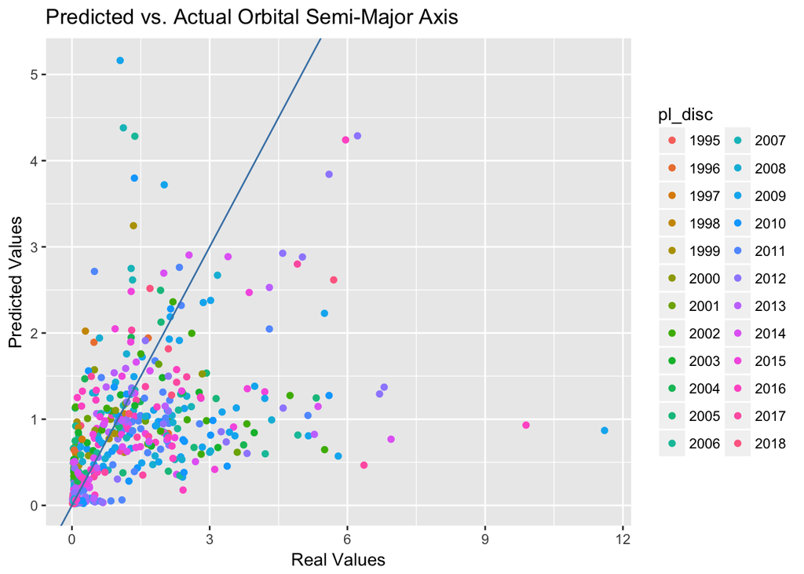

```r
ggplot(planets_good) +
  geom_point(aes(x=pl_orbsmax, y=exp(best_fit$fitted.values), color = pl_disc)) +
  geom_abline(slope = 1,
              intercept = 0,
              col = 'steelblue') +
  xlab("Real Values") +
  ylab("Predicted Values") +
  ggtitle("Predicted vs. Actual Orbital Semi-Major Axis")
```

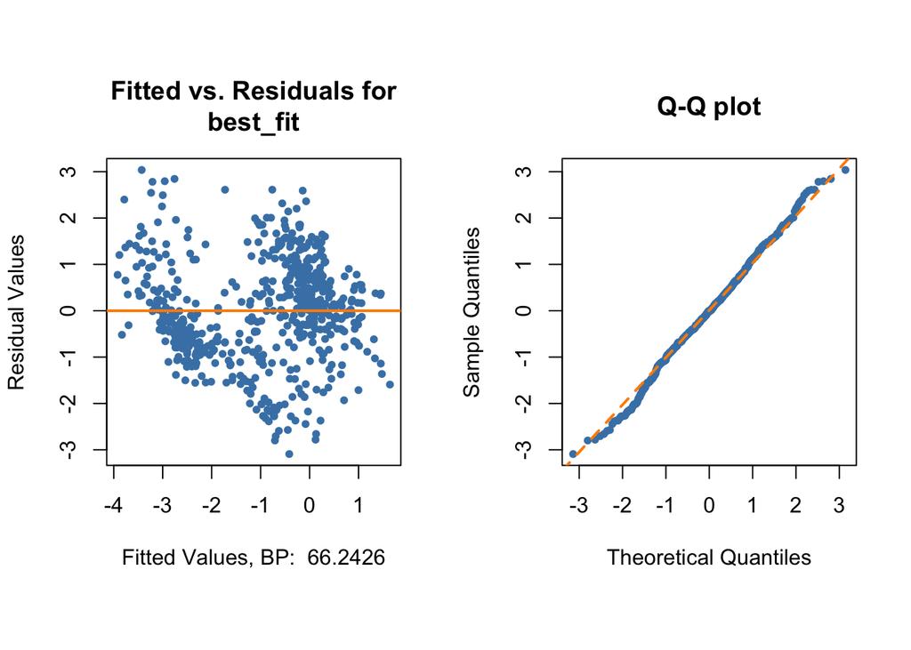

```
## $p_val
## [1] 0.3714
##
## $decision
## [1] "Fail to Reject"
##
## $bpp
##
##  studentized Breusch-Pagan test
##
## data:  model
## BP = 66, df = 9, p-value = 8e-11
```

```r
diagnostics(best_fit, pcol = 'steelblue', lcol = 'darkorange')
```

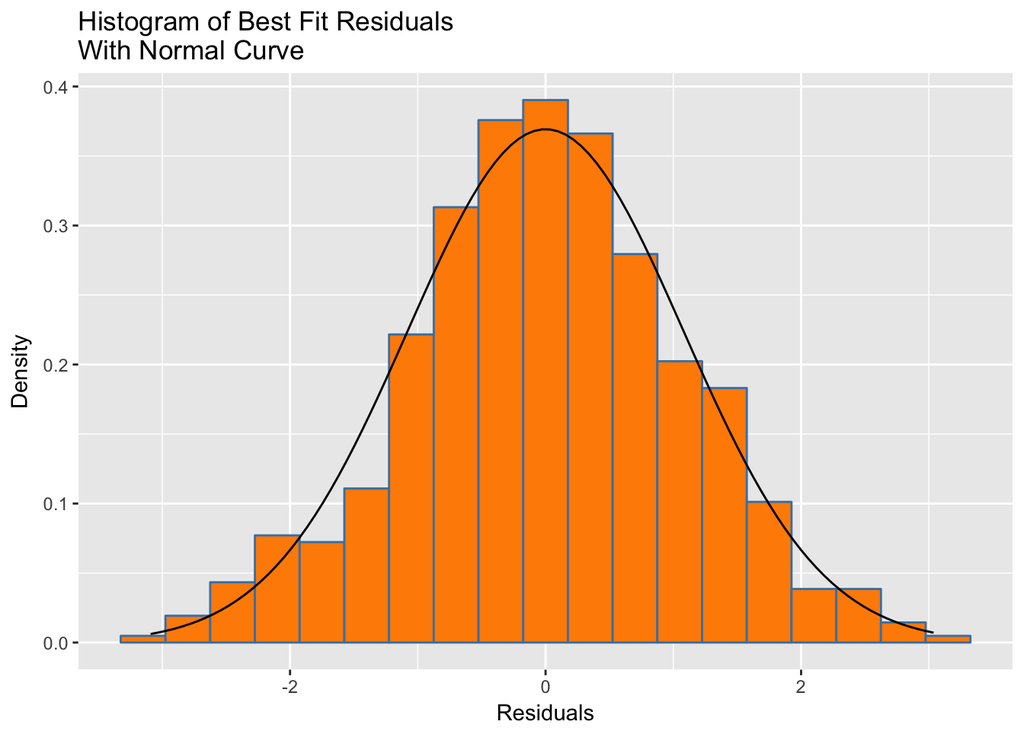

```r
ggplot() + aes(resid(best_fit)) +
  geom_histogram(aes(y = ..density..),
                 binwidth=.35,
                 colour="steelblue",
                 fill="dark orange") +
  ggtitle("Histogram of Best Fit Residuals\nWith Normal Curve") +
  xlab("Residuals") +
  ylab("Density") +
  stat_function(fun=dnorm,
                         color="black",
                         args=list(mean=mean(resid(best_fit)),
                                   sd=sd(resid(best_fit))))
```

## Confidence intervals By Year (pl_disc)

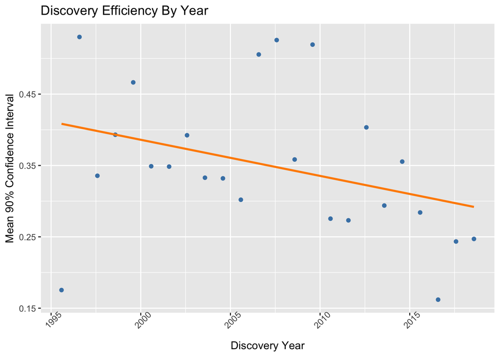

```r
years <- sort(unique(planets_good$pl_disc))
#as.numeric(years)
yearly_predict_range <- data.frame(year = rep(0,length(years)),
                             span = rep(0,length(years)))

for (i in seq(1:length(years))){
  temp_pred <- exp(predict(best_fit,
                           newdata = planets_good[planets_good$pl_disc == as.character(years[i]),],
                           interval = "confidence",
                           level = 0.90))
  yearly_predict_range[i,] <- c(as.character(years[i]),
                          mean(temp_pred[,3]) - mean(temp_pred[,2]))
}


ggplot(yearly_predict_range, aes(x=as.Date(year, "%Y"), y=as.numeric(span))) +
  geom_point(col = 'steelblue') +
  xlab("Discovery Year") +
  ylab("Mean 90% Confidence Interval") +
  ggtitle("Discovery Efficiency By Year") +
  theme(axis.text.x = element_text(angle=45)) +
  geom_smooth(method = "lm", se = FALSE,
              col = 'darkorange')
```